# Homework 1

PSTAT 131/231

Baiming Wang

## Machine Learning Main Ideas

Please answer the following questions. Be sure that your solutions are clearly marked and that your document is neatly formatted.

You don’t have to rephrase everything in your own words, but if you quote directly, you should cite whatever materials you use (this can be as simple as “from the lecture/page # of book”).

### Question 1:

Define supervised and unsupervised learning. What are the difference(s) between them? **Supervised learning is machine learning on data sets that, for each observation of predictor/input variables, there is a response/output variable, and we fit a model that relates the response to the predictors. (paraphrasing ISLR, p26). Unsupervised learning is when said response/output variable does not exist. We can look for relationships between variables and patterns, trends, and clusters within the data in this situation.**

### Question 2:

Explain the difference between a regression model and a classification model, specifically in the context of machine learning.  
**The outcome/response variable of a regression model is quantitative, whereas it is qualitative for a classification model.**

### Question 3:

Name two commonly used metrics for regression ML problems. Name two commonly used metrics for classification ML problems.

**R-squared and Mean Squared Error are two metrics to evaluate regression ML models; Error rate, precision, and sensitivity(recall) are three metrics to evaluate classification ML models.**  
For the latter question, my answer is partially based on https://www.analyticsvidhya.com/blog/2021/07/metrics-to-evaluate-your-classification-model-to-take-the-right-decisions/

### Question 4:

As discussed, statistical models can be used for different purposes. These purposes can generally be classified into the following three categories. Provide a brief description of each.

- Descriptive models: **Descriptive models are models used to describe and illustrate characteristics of a data set. For instance, they can be used to visualize trends and patterns within data.**
- Inferential models: **Inferential models are models used to make inferences of the associations of variables. For instance, they can help test theories about correlative and causal relationships between variables. Their aim is to understand and perhaps explain those relationships.**
- Predictive models: **Predictive models are models used to predict the value of an output variable with a set of available input variables. It is often used when the true value of the output variable is difficult to obtain. Their aim is to accurately predict the output variable.**

### Question 5:

Predictive models are frequently used in machine learning, and they can usually be described as either mechanistic or empirically-driven. Answer the following questions.

- Define mechanistic. Define empirically-driven. How do these model types differ? How are they similar? **Mechanistic models are those that assume a parametric form of the function from input variables to the output variable. They adjust the parameters of that function to get close to the data points. Empirically-driven models don’t make those assumption. They utilize different forms of functions to get close to the true function between output and input variables.** **The key difference is whether or not there is an assumption about the form of the function. Consequently, empirically-driven models are usually more flexible, but require more data. It might be harder to explain empirically-driven models because they may come in unexpected forms.** **There are similarities. For instance, both kinds of models are vulnerable to overfitting.**
- In general, is a mechanistic or empirically-driven model easier to understand? Explain your choice. **I think mechanistic models are easier to understand. We make assumptions about the function between output and input variables, and those assumptions usually arise from existing empirical and scientific knowledge. In other words, these models are easier to understand and explain because our assumptions are typically reasonable in the first place. On the other hand, empirically-driven models are highly mathematical, and such numerical analysis can produce unexpected and convoluted estimator functions that are very hard to contextually understand and explain.**
- Describe how the bias-variance tradeoff is related to the use of mechanistic or empirically-driven models. **If we use a rather unsophisticated mechanistic or empirically-driven model on a training data set, we should expect a large bias. But, since the model is rather unsophisticated, it should change little had we chosen a different training set, hence a small variance. As the model gets more complex, the bias decreases, but the variance increases as our model becomes more sample-dependent (i.e., picking up the noise within the specific data set). This is the bias-variance trade-off.**

### Question 6:

A political candidate’s campaign has collected some detailed voter history data from their constituents. The campaign is interested in two questions:

- Given a voter’s profile/data, how likely is it that they will vote in favor of the candidate? **Predictive. The campaign is interested in accurately predicting whether the voter will vote for the candidate, but uninterested in which factors lead to that vote and how.**
- How would a voter’s likelihood of support for the candidate change if they had personal contact with the candidate? **Inferential. The campaign is interested in the specific correlation (and possibly causation) between personal contacts with a voter and the likelihood of the voter’s support, which is a statistical inference.**

Classify each question as either predictive or inferential. Explain your reasoning for each.

## Exploratory Data Analysis

This section will ask you to complete several exercises. For this homework assignment, we’ll be working with the `mpg` data set that is loaded when you load the tidyverse. Make sure you load the tidyverse and any other packages you need.

Exploratory data analysis (or EDA) is not based on a specific set of rules or formulas. It is more of a state of curiosity about data. It’s an iterative process of:

- generating questions about data
- visualize and transform your data as necessary to get answers
- use what you learned to generate more questions

A couple questions are always useful when you start out. These are “what variation occurs within the variables,” and “what covariation occurs between the variables.”

You should use the tidyverse and `ggplot2` for these exercises.

### Exercise 1:

We are interested in highway miles per gallon, or the `hwy` variable. Create a histogram of this variable. Describe what you see/learn.

**Solutions:**

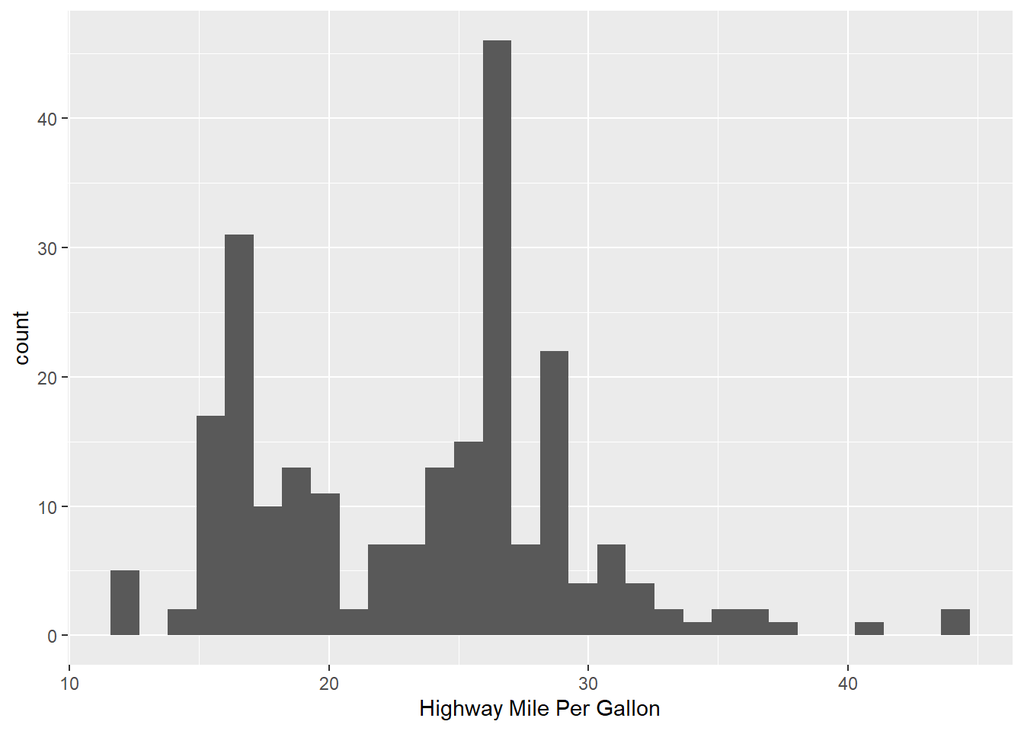

**It is a bimodal distribution with one peak at around 17 and another at around 27. It suggests that one can possibly separate cars into two groups by highway fuel efficiency.**

### Exercise 2:

Create a scatterplot. Put `hwy` on the x-axis and `cty` on the y-axis. Describe what you notice. Is there a relationship between `hwy` and `cty`? What does this mean?

**Solutions:**

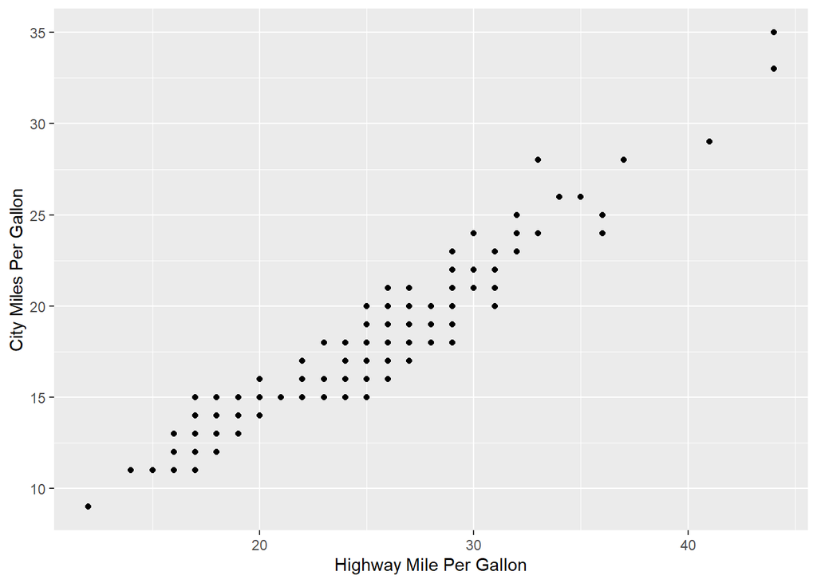

**There is a rather strong relationship. Hwy and cty are positively and linearly correlated. This means that, for a car in this data set, the higher its highway mileage per gallon, the higher its city mileage per gallon.**

### Exercise 3:

Make a bar plot of `manufacturer`. Flip it so that the manufacturers are on the y-axis. Order the bars by height. Which manufacturer produced the most cars? Which produced the least?

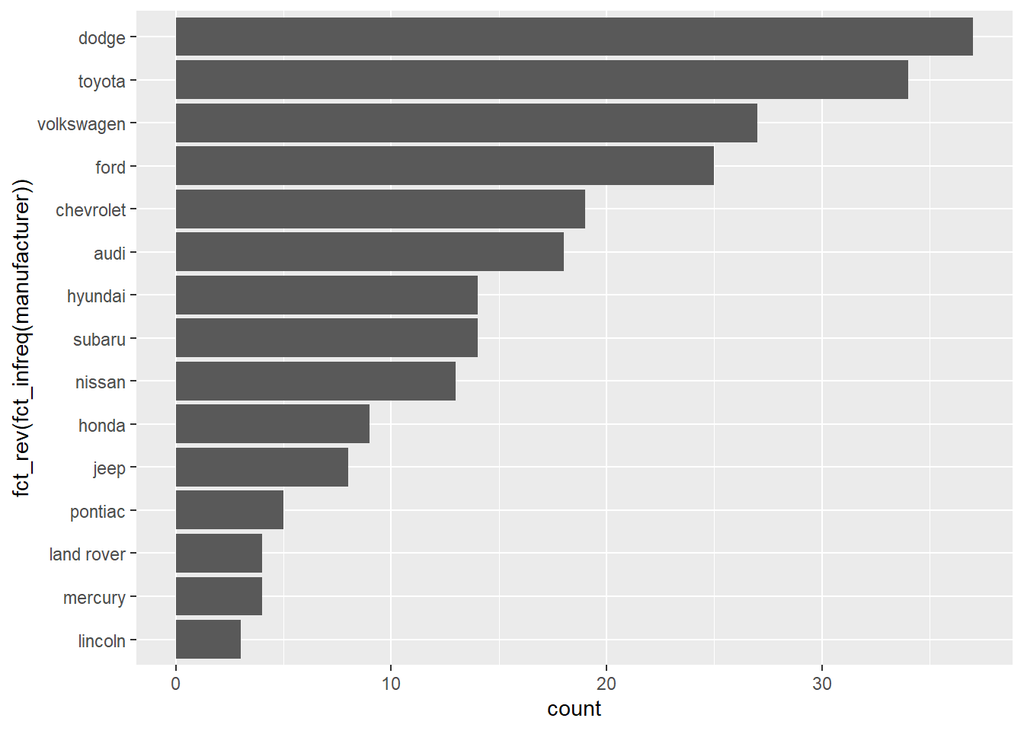

**Dodge produced the most cars, whereas Lincoln produced the least.**

### Exercise 4:

Make a box plot of `hwy`, grouped by `cyl`. Do you see a pattern? If so, what?

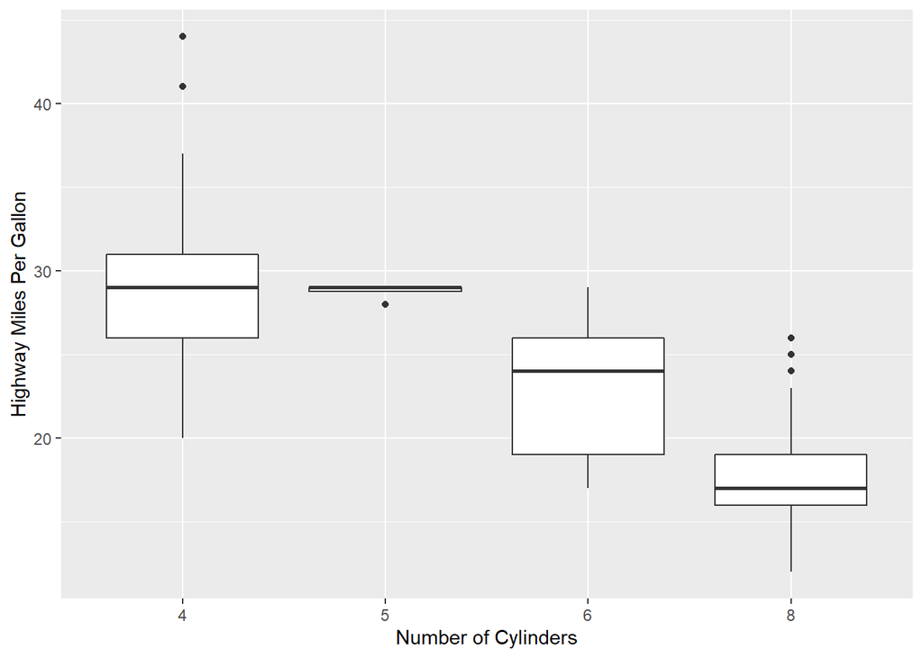

**Yes, there is a pattern. Broadly speaking, the more cylinders a car has, the lower its mileage per gallon is.**

### Exercise 5:

Use the `corrplot` package to make a lower triangle correlation matrix of the `mpg` dataset. (Hint: You can find information on the package [here.](https://cran.r-project.org/web/packages/corrplot/vignettes/corrplot-intro.html))

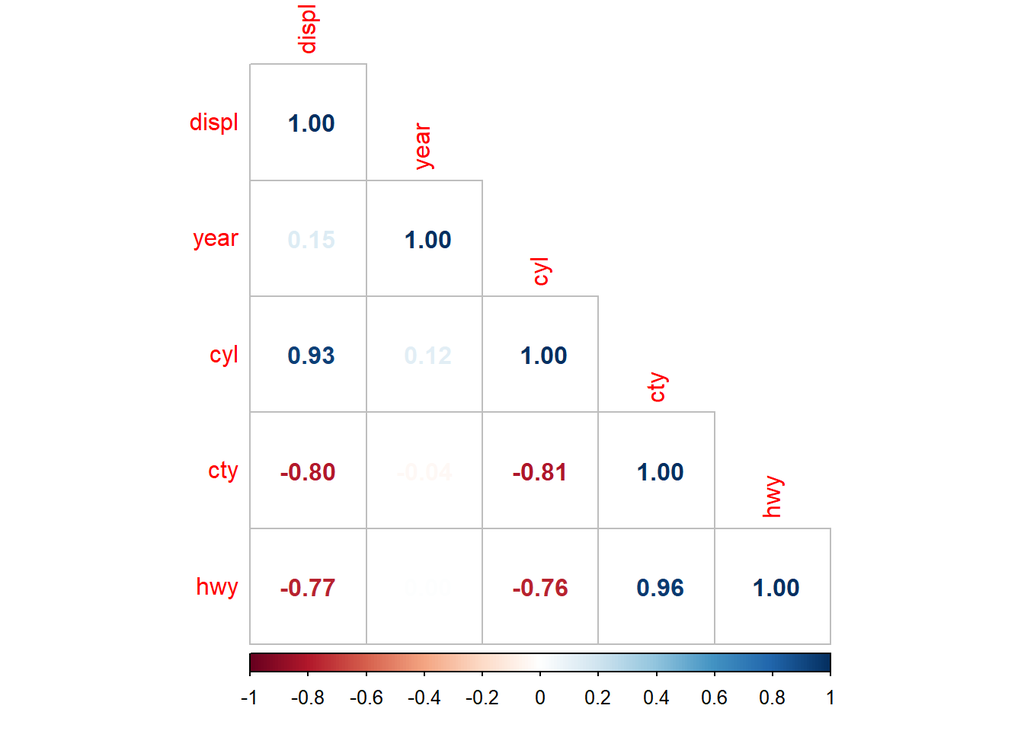

Which variables are positively or negatively correlated with which others? Do these relationships make sense to you? Are there any that surprise you?

**‘displ’ is strongly positively correlated with ‘cyl’, and rather strongly negatively correlated with ‘cty’ and ‘hwy’. ‘’cyl’ is rather strongly negatively correlated with ‘cty’ and ‘hwy’. ‘cty’ is strongly positively correlated with ‘hwy’. ‘year’ is pretty much uncorrelated with all other variables.**  
**I’m sure these relationships will make sense to me if I knew more about cars. I googled the terms and they mostly make sense. The only mild surprise is that ‘year’ is not related to any other variable. I guess technology didn’t advance much during that period.**

### 231 Students Only:

#### Exercise 6:

**My Attempt**

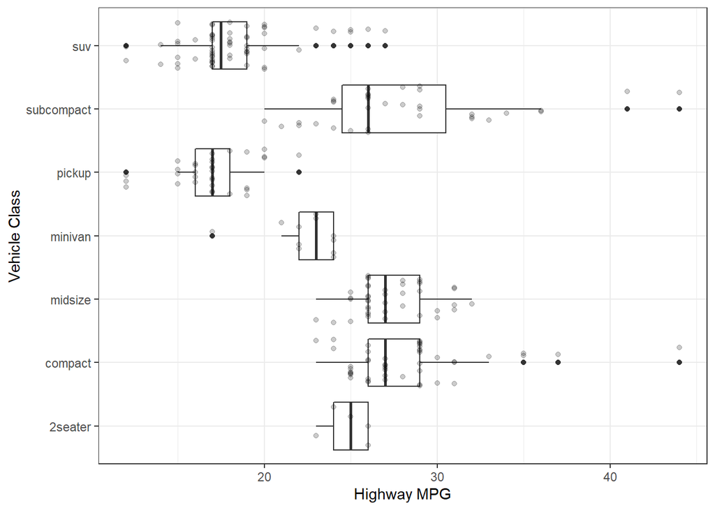

#### Exercise 7

**My Attempt**

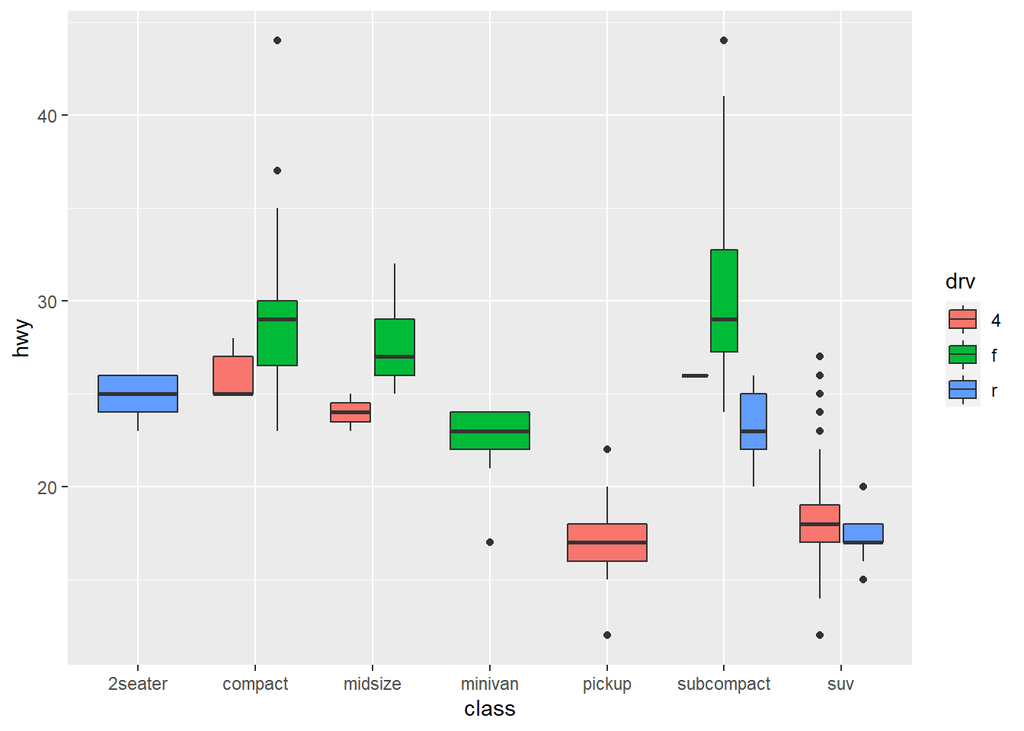

#### Exercise 8

**My Attempt**

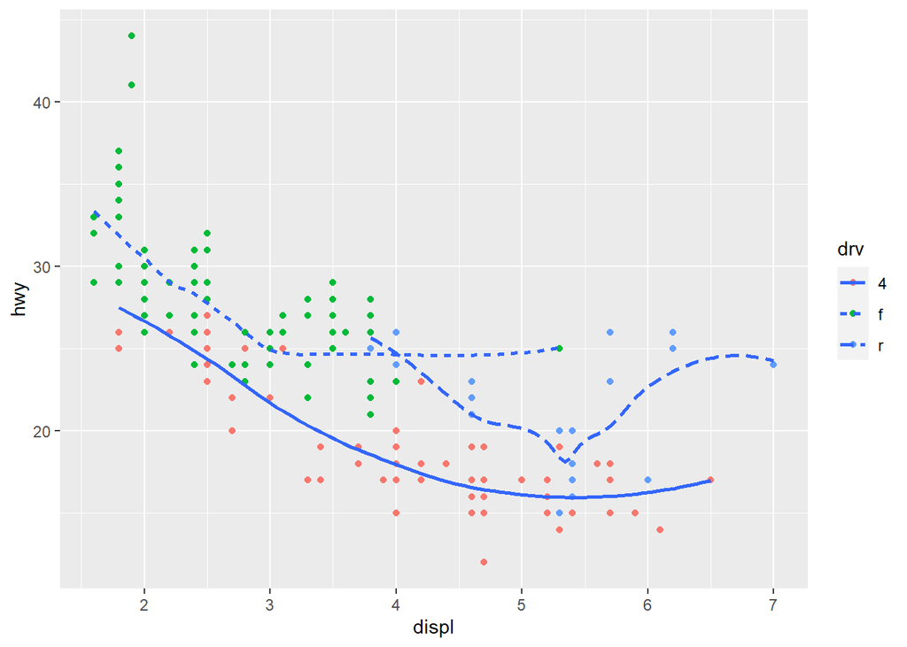